# TDS WDL data analysis

2025-02-27

# Purpose

```
##
##
##
##
##
## here() starts at C:/Users/krein/OneDrive - California Department of Water Resources/Documents/TDS Study 2025
```

# Import data (good)

```r
# Pull in all original WDL data sets into one dataframe
# Unzip folder containing WDL data to a temporary directory
unzip(zipfile = here("WDL_data.zip"), exdir = tempdir())

filelist <- list.files(
  path = file.path(tempdir(), "WDL_data"),
  pattern = "*.csv$",
  full.names = FALSE
)

dset <-
  list.files(
    file.path(tempdir(), "WDL_data"),
    pattern = "*.csv$",
    full.names = TRUE
  ) %>%
  lapply(read.csv)
```

##Check file (good)

```r
attr(dset, "names") <- filelist

dset1 <- rbindlist(dset, idcol= "id", fill = TRUE)

dset1 <- clean_names(dset1)

View(dset1)

names(dset1)
```

```
##  [1] "id"                 "data_owner"         "data_status"
##  [4] "long_station_name"  "short_station_name" "station_number"
##  [7] "sample_code"        "collection_date"    "analyte"
## [10] "cas_reg_number"     "lab_dup"            "result"
## [13] "rpt_limit"          "units"              "method"
## [16] "depth"              "matrix"             "sample_type"
## [19] "parent_sample"      "description"        "notes"
## [22] "result_rejected"
```

```r
unique(dset1$analyte)
```

```
##  [1] "Dissolved Chloride"
##  [2] "Total Dissolved Solids"
##  [3] "Total Suspended Solids"
##  [4] "Field Chlorophyll Volume"
##  [5] "Field Specific Conductance"
##  [6] "Field Water Temperature"
##  [7] ""
##  [8] "Specific Conductance"
##  [9] "Field (Bottom) Chlorophyll Fluorescence"
## [10] "Field Chlorophyll Fluorescence"
## [11] "Field (Bottom) Specific Conductance"
## [12] "Field Microcystis aeruginosa"
## [13] "Field (Bottom) Dissolved Oxygen"
## [14] "Field Dissolved Oxygen"
## [15] "Field (Bottom) pH"
```

[output cut: 25 more lines]

#TDS sample count ##Filter out unnecessary analytes. Keep related analytes by container, analyte relationship. -TDS (primary analyte of interest) -Bromide, Chloride, Nitrate, Sulfate (currently collected alongside TDS in same container) -TSS (possibly will be submitted alongside TDS in container post-TDS processing change) -Field & Lab SC (relationship to TDS)

```r
# filter out all unneeded analytes since all field parameters were exported
dset2 <- filter(dset1, analyte == "Field Specific Conductance" | analyte == "Dissolved Sulfate" | analyte == "Total Dissolved Solids"
                | analyte == "Total Suspended Solids" | analyte == "Dissolved Nitrate" | analyte == "Specific Conductance"
                | analyte == "Dissolved Bromide" | analyte == "Dissolved Chloride")
```

## count number of TDS QC samples (in a TDS-specific dataframe) (good)

```r
#count lab dups, field collected blanks, and field dups submitted for TDS
dset2_tds <- filter(dset2, analyte == "Total Dissolved Solids")

str(dset2_tds)
```

```
## Classes 'data.table' and 'data.frame':   1914 obs. of  22 variables:
##  $ id                : chr  "AEU_TDS+_06012023_05312024.csv" "AEU_TDS+_06012023_05312024.csv" "AEU_TDS+_06012023_05312024.csv" "AEU_TDS+_06012023_05312024.csv" ...
##  $ data_owner        : chr  "0330" "0330" "0330" "0330" ...
##  $ data_status       : chr  "1000 - Non-Public, Review Status Unknown" "1000 - Non-Public, Review Status Unknown" "1000 - Non-Public, Review Status Unknown" "1000 - Non-Public, Review Status Unknown" ...
##  $ long_station_name : chr  "Toe Drain at Rotary Screw Trap" "Yolo Bypass Toe Drain Below Lisbon Weir" "Sacramento River @ Sherwood Harbor" "Sacramento River @ Sherwood Harbor" ...
##  $ short_station_name: chr  "Toe Drain at STTD" "Toe Drain YB LISBON" "SHER" "SHER" ...
##  $ station_number    : chr  "A0D82120386" "B9D82851352" "A0200000" "A0200000" ...
##  $ sample_code       : chr  "ES0124B0001" "ES0124B0002" "ES0124B0003" "ES0124B0003" ...
##  $ collection_date   : chr  "01/08/2024 09:19" "01/08/2024 13:53" "01/09/2024 10:11" "01/09/2024 10:11" ...
##  $ analyte           : chr  "Total Dissolved Solids" "Total Dissolved Solids" "Total Dissolved Solids" "Total Dissolved Solids" ...
##  $ cas_reg_number    : chr  "0" "0" "0" "0" ...
##  $ lab_dup           : chr  "" "" "Y" "" ...
##  $ result            : chr  "313" "294" "132" "131" ...
##  $ rpt_limit         : num  2.5 2.5 2.5 2.5 2.5 2.5 2.5 2.5 2.5 2.5 ...
##  $ units             : chr  "mg/L" "mg/L" "mg/L" "mg/L" ...
##  $ method            : chr  "Std Method 2540 C [1]*" "Std Method 2540 C [1]*" "Std Method 2540 C [1]*" "Std Method 2540 C [1]*" ...
##  $ depth             : chr  "0 Meters" "0 Meters" "0 Meters" "0 Meters" ...
##  $ matrix            : chr  "Water, Natural" "Water, Natural" "Water, Natural" "Water, Natural" ...
##  $ sample_type       : chr  "Normal Sample" "Normal Sample" "Normal Sample" "Normal Sample" ...
##  $ parent_sample     : chr  "0" "0" "0" "0" ...
##  $ description       : chr  "" "" "" "" ...
##  $ notes             : chr  "" "" "" "" ...
##  $ result_rejected   : chr  "N" "N" "N" "N" ...
##  - attr(*, ".internal.selfref")=<externalptr>
```

```r
#remove collection time from collection date field to help out later with linking duplicates since collection time can be different
dset2_tds <- mutate(dset2_tds, collection_date = as.Date(collection_date, format = '%m/%d/%Y'))

dset2_tds_qc <- mutate(dset2_tds, qc_category = case_when(lab_dup == "Y"~"lab_dup",
                       grepl("Blank", sample_type)~"field_blank",
                       grepl("Replicate", sample_type) | grepl("Duplicate", sample_type) & lab_dup !="Y"~"field_dup",
                       TRUE~"normal"))

count(dset2_tds_qc, qc_category)
```

```
##    qc_category     n
##         <char> <int>
## 1: field_blank   165
## 2:   field_dup   179
## 3:     lab_dup   184
## 4:      normal  1386
```

```r
#qc_category     n
#<char> <int>
#1: field_blank   165
#2:   field_dup   179
#3:     lab_dup   184
#4:      normal  1386
```

# Samples across containers

## remove all QC samples in TDS data frame (good)

```r
#remove all qc samples
dset3_tds <- filter(dset2_tds_qc, qc_category == "normal")
#remaining normal TDS samples: 1386
```

## remove duplicate values across all analytes (good)

```r
#pull back in other analytes of interest to parse out qc samples, need to account for lab dups that are done on a field duplicate
#this doesn't properly account for field dups which serve as parent for lab dup RPD so need to account for that later
dset2_qc <- mutate(dset2, qc_category = case_when(lab_dup == "Y"~"lab_dup",
                                                     grepl("Blank", sample_type)~"field_blank",
                                                     grepl("Replicate", sample_type) | grepl("Duplicate", sample_type) & lab_dup !="Y"~"field_dup",
                                                     TRUE~"normal"))

#remove all qc samples
dset3_qc <- filter(dset2_qc, qc_category == "normal")

# Look for duplicates using analyte, sample code, as unique identifiers
r = dset3_qc %>%
  count(sample_code, analyte) %>%
  filter(n > 1)

#there are 32 duplicates, 2 are dissolved chloride and remainder are field specific conductance.I brought up Chloride observation to QA and data owner to handle
#separately, will choose first value. Spot checking the Field SC duplicates, there is a different status assigned but values are the same. Also choosing first value

#pivot wider to group by sample ID, pick first instance of sample ID present to remove these 34 dup values
dset3_qc_wide <- dset3_qc %>%
  pivot_wider(id_cols = c(sample_code, data_owner, station_number),
              names_from = analyte, values_from = result,
              values_fill = NA, values_fn = first)

dset3_qc_wide <- clean_names(dset3_qc_wide)
```

## Confirm no duplicates using sample code (good)

```r
dset3_qc_wide %>%
  count(sample_code) %>%
  filter(n > 1)
```

```
## # A tibble: 0 × 2
## # ℹ 2 variables: sample_code <chr>, n <int>
```

```r
#no duplicates so good to go

str(dset3_qc_wide)
```

```
## tibble [1,769 × 11] (S3: tbl_df/tbl/data.frame)
##  $ sample_code               : chr [1:1769] "ES0124B0001" "ES0124B0002" "ES0124B0003" "ES0124B0011" ...
##  $ data_owner                : chr [1:1769] "0330" "0330" "0330" "0330" ...
##  $ station_number            : chr [1:1769] "A0D82120386" "B9D82851352" "A0200000" "B9D82851352" ...
##  $ dissolved_chloride        : chr [1:1769] "20.6" "19.7" "6.88" "25.5" ...
##  $ total_dissolved_solids    : chr [1:1769] "313" "294" "131" "314" ...
##  $ total_suspended_solids    : chr [1:1769] "34" "25.9" "24.3" "51.1" ...
##  $ field_specific_conductance: chr [1:1769] " 480" " 465" " 200" " 514" ...
##  $ specific_conductance      : chr [1:1769] NA NA NA NA ...
##  $ dissolved_bromide         : chr [1:1769] NA NA NA NA ...
##  $ dissolved_sulfate         : chr [1:1769] NA NA NA NA ...
##  $ dissolved_nitrate         : chr [1:1769] NA NA NA NA ...
```

##filter out any samples without TDS (good)

```r
dset3_qc_wide <- dset3_qc_wide %>%
  drop_na(total_dissolved_solids)

#number of samples with just TDS is 1386, total observations in dset3qc_wide
```

##count total number of samples analyzed for TDS and also anions (good)

```r
#create new analyte column for any anions methods
dset4_qc_wide <- mutate(dset3_qc_wide, anions = case_when(dissolved_sulfate != "NA" | dissolved_bromide != "NA" | dissolved_chloride != "NA"
                                                    | dissolved_nitrate != "NA" ~ 'yes', TRUE ~ 'no'))

#number of samples with TDS and any of dissolved sulfate, nitrate, bromide, chloride
count(dset4_qc_wide, anions == "yes") #1351 TDS samples also submitted for any anions, 35 not
```

```
## # A tibble: 2 × 2
##   `anions == "yes"`     n
##   <lgl>             <int>
## 1 FALSE                35
## 2 TRUE               1351
```

##count total number of samples analyzed for TDS and also TSS (good)

```r
#number of samples with TDS and TSS
count(dset4_qc_wide, total_suspended_solids !="NA") #1046 TDS samples also submitted for TSS, 340 not
```

```
## # A tibble: 2 × 2
##   `total_suspended_solids != "NA"`     n
##   <lgl>                            <int>
## 1 TRUE                              1046
## 2 NA                                 340
```

#TDS dataset summary ## reformat so concentrations are numeric (good)

```r
#reformat remaining fields
dset4_qc_wide <- mutate(dset4_qc_wide, total_dissolved_solids = as.numeric(total_dissolved_solids),
                      total_suspended_solids = as.numeric(total_suspended_solids),
                     field_specific_conductance = as.numeric(field_specific_conductance),
                     specific_conductance = as.numeric(specific_conductance),
                     dissolved_sulfate = as.numeric(dissolved_sulfate),
                     dissolved_bromide = as.numeric(dissolved_bromide),
                     dissolved_chloride = as.numeric(dissolved_chloride),
                     dissolved_nitrate = as.numeric(dissolved_nitrate))
str(dset4_qc_wide)
```

```
## tibble [1,386 × 12] (S3: tbl_df/tbl/data.frame)
##  $ sample_code               : chr [1:1386] "ES0124B0001" "ES0124B0002" "ES0124B0003" "ES0124B0011" ...
##  $ data_owner                : chr [1:1386] "0330" "0330" "0330" "0330" ...
##  $ station_number            : chr [1:1386] "A0D82120386" "B9D82851352" "A0200000" "B9D82851352" ...
##  $ dissolved_chloride        : num [1:1386] 20.6 19.7 6.88 25.5 25.6 5.58 20.9 23.5 4.26 8.39 ...
##  $ total_dissolved_solids    : num [1:1386] 313 294 131 314 315 107 261 281 97 144 ...
##  $ total_suspended_solids    : num [1:1386] 34 25.9 24.3 51.1 76.3 47.4 199 124 95.7 23 ...
##  $ field_specific_conductance: num [1:1386] 480 465 200 514 517 163 420 455 139 227 ...
##  $ specific_conductance      : num [1:1386] NA NA NA NA NA NA NA NA NA NA ...
##  $ dissolved_bromide         : num [1:1386] NA NA NA NA NA NA NA NA NA NA ...
##  $ dissolved_sulfate         : num [1:1386] NA NA NA NA NA NA NA NA NA NA ...
##  $ dissolved_nitrate         : num [1:1386] NA NA NA NA NA NA NA NA NA NA ...
##  $ anions                    : chr [1:1386] "yes" "yes" "yes" "yes" ...
```

#summary of TDS values & data visualization (good)

```r
summary(dset4_qc_wide$total_dissolved_solids)
```

```
##    Min. 1st Qu.  Median    Mean 3rd Qu.    Max.
##    28.5    93.0   169.5  1335.7   354.0 29400.0
```

```r
#Min. 1st Qu.  Median    Mean 3rd Qu.    Max.
#28.5    93.0   169.5  1335.7   354.0 29400.0

dset3_tds %>%
  count(sample_code) %>%
  filter(n > 1)
```

```
## Empty data.table (0 rows and 2 cols): sample_code,n
```

```r
#no duplicates so good to go

#pivot wider to group by sample ID
dset3_tds_wide <- dset3_tds %>%
  pivot_wider(id_cols = c(sample_code, collection_date, data_owner, station_number),
              names_from = analyte, values_from = result)

dset3_tds_wide <- clean_names(dset3_tds_wide)

str(dset3_tds_wide)
```

```
## tibble [1,386 × 5] (S3: tbl_df/tbl/data.frame)
##  $ sample_code           : chr [1:1386] "ES0124B0001" "ES0124B0002" "ES0124B0003" "ES0124B0011" ...
##  $ collection_date       : Date[1:1386], format: "2024-01-08" "2024-01-08" ...
##  $ data_owner            : chr [1:1386] "0330" "0330" "0330" "0330" ...
##  $ station_number        : chr [1:1386] "A0D82120386" "B9D82851352" "A0200000" "B9D82851352" ...
##  $ total_dissolved_solids: chr [1:1386] "313" "294" "131" "314" ...
```

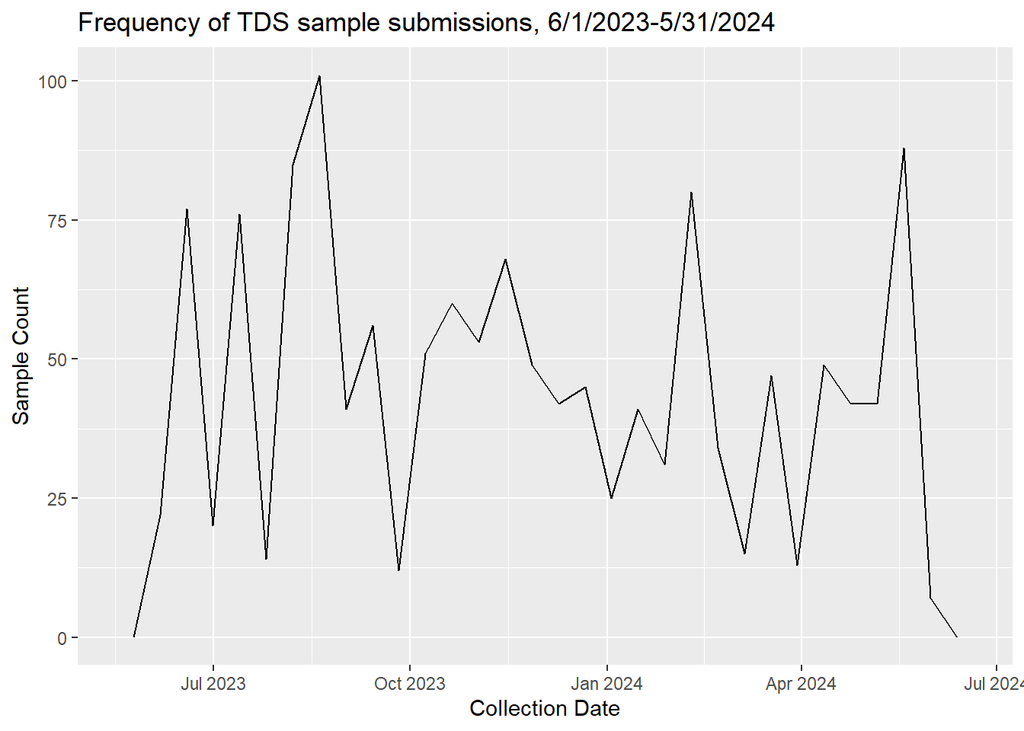

```r
#reformat results to numeric
dset3_tds_wide <- mutate(dset3_tds_wide, total_dissolved_solids = as.numeric(total_dissolved_solids))

#breakdown TDS sample submissions by date
ggplot(dset3_tds_wide, aes(x = collection_date)) +
  geom_freqpoly()+
  labs(
    title = "Frequency of TDS sample submissions, 6/1/2023-5/31/2024",
    x = "Collection Date",
    y = "Sample Count"
  )
```

```r
#breakdown TDS concentration frequency observed

count(dset3_tds_wide, total_dissolved_solids > 20000)
```

```
## # A tibble: 2 × 2
##   `total_dissolved_solids > 20000`     n
##   <lgl>                            <int>
## 1 FALSE                             1363
## 2 TRUE                                23
```

```r
#23 out of 1386 TDS samples with concentration > 20,000 mg/L = 1.66% of samples

count(dset3_tds_wide, total_dissolved_solids > 10000)
```

```
## # A tibble: 2 × 2
##   `total_dissolved_solids > 10000`     n
##   <lgl>                            <int>
## 1 FALSE                             1330
## 2 TRUE                                56
```

```r
#56 out of 1386 TDS samples with concentration > 10,000 mg/L = 4.04% of samples

count(dset3_tds_wide, total_dissolved_solids > 2500)
```

```
## # A tibble: 2 × 2
##   `total_dissolved_solids > 2500`     n
##   <lgl>                           <int>
## 1 FALSE                            1240
## 2 TRUE                              146
```

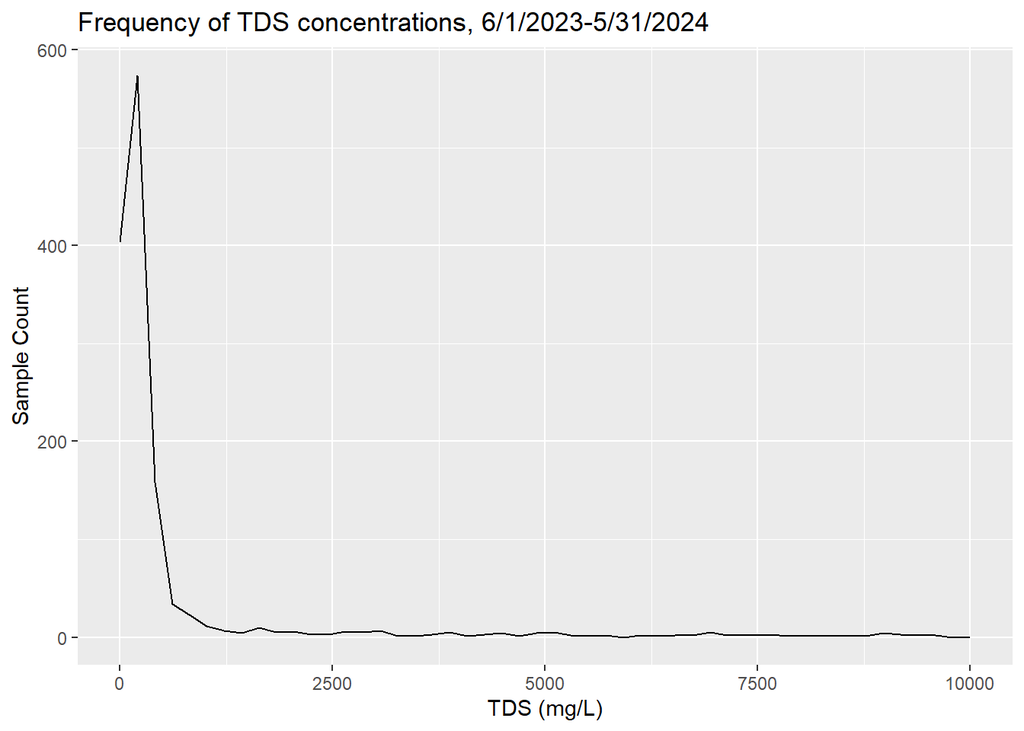

```r
#146 out of 1386 TDS samples with concentration > 2500 mg/L = 10.5% of samples

ggplot(dset3_tds_wide, aes(x = total_dissolved_solids)) +
  geom_freqpoly(bins=50)+
  xlim(0, 10000)+
  labs(
    title = "Frequency of TDS concentrations, 6/1/2023-5/31/2024",
    x = "TDS (mg/L)",
    y = "Sample Count"
  )
```

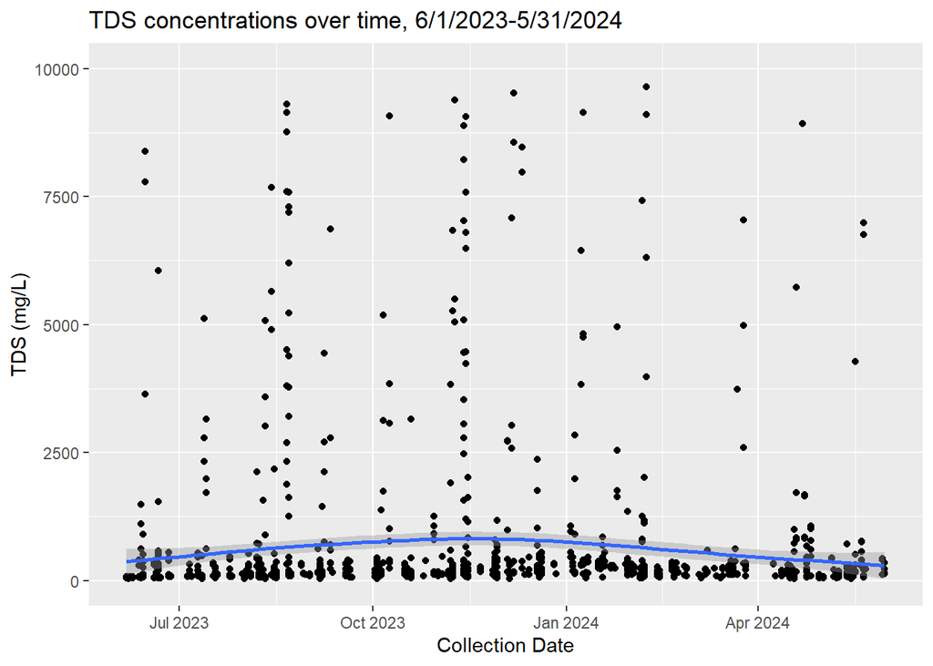

```r
ggplot(dset3_tds_wide, aes(x = collection_date, y= total_dissolved_solids)) +
  geom_point()+
  geom_smooth()+
  ylim(0, 10000)+
  labs(
    title = "TDS concentrations over time, 6/1/2023-5/31/2024",
    x = "Collection Date",
    y = "TDS (mg/L)"
  )
```

## Breakdown TDS into concentrations

```r
dset3_tds_wide_conc = mutate(dset3_tds_wide, tds_conc_grp = case_when(total_dissolved_solids < 50 & total_dissolved_solids >= 2.5~"<49",
                                                         total_dissolved_solids < 100 & total_dissolved_solids >= 50 ~"50-99",
                                                        total_dissolved_solids < 150 & total_dissolved_solids >= 100 ~"100-149",
                                                         total_dissolved_solids < 200 & total_dissolved_solids >= 150 ~"150-199",
                                                         total_dissolved_solids < 250 & total_dissolved_solids >= 200 ~"200-249",
                                                         total_dissolved_solids < 300 & total_dissolved_solids >= 250~"250-299",
                                                         total_dissolved_solids < 400 & total_dissolved_solids >= 300~"300-399",
                                                         total_dissolved_solids < 500 & total_dissolved_solids >= 400~"400-499",
                                                         total_dissolved_solids < 600 & total_dissolved_solids >= 500~"500-599",
                                                         total_dissolved_solids < 700 & total_dissolved_solids >= 600~"600-699",
                                                         total_dissolved_solids < 800 & total_dissolved_solids >= 700~"700-799",
                                                         total_dissolved_solids < 900 & total_dissolved_solids >= 800~"800-899",
                                                         total_dissolved_solids < 1000 & total_dissolved_solids >= 900~"900-999",
                                                         total_dissolved_solids < 2000 & total_dissolved_solids >= 1000~"1000-1999",
                                                         total_dissolved_solids < 3000 & total_dissolved_solids >= 2000~"2000-2999",
                                                         total_dissolved_solids < 4000 & total_dissolved_solids >= 3000~"3000-3999",
                                                         total_dissolved_solids < 5000 & total_dissolved_solids >= 4000~"4000-4999",
                                                     TRUE ~ ">=5000") %>%
                        factor(levels = c("<49", "50-99", "100-149", "150-199", "200-249", "250-299", "300-399", "400-499", "500-599", "600-699", "700-799", "800-899", "900-999", "1000-1999", "2000-2999",
                       "3000-3999", "4000-4999", ">=5000")))

df_conc_grp <- dset3_tds_wide_conc %>%
   group_by(tds_conc_grp) %>%
   summarize(n = n())

df_conc_grp
```

```
## # A tibble: 18 × 2
##    tds_conc_grp     n
##    <fct>        <int>
##  1 <49             26
##  2 50-99          369
##  3 100-149        239
##  4 150-199        127
##  5 200-249        111
##  6 250-299         99
##  7 300-399        109
##  8 400-499         53
##  9 500-599         21
## 10 600-699         12
## 11 700-799         15
## 12 800-899          8
## 13 900-999          6
## 14 1000-1999       36
## 15 2000-2999       21
## 16 3000-3999       18
## 17 4000-4999       12
## 18 >=5000         104
```

#Evaluate Field and Lab variance via RPD ## Evaluate lab variance using Lab Dup RPD for TDS

```r
#reassign qc category to properly assign "parent" to lab dup due to earlier issue with the parent samples that are classified as field dup
lab_dup1 <- mutate(dset2_tds, lab_dup_category = case_when(lab_dup == "Y"~"lab_dup",
                                                            TRUE~"not_dup"))

lab_dup1_wide <- lab_dup1 %>%
  pivot_wider(id_cols = c(long_station_name, data_owner, sample_code, collection_date),
              names_from = lab_dup_category, values_from = result,
              values_fill = NA)

lab_dup1_wide2 <- filter(lab_dup1_wide, lab_dup !="NA")
#count of 184 lab dups is same as earlier, good to go

str(lab_dup1_wide2)
```

```
## tibble [184 × 6] (S3: tbl_df/tbl/data.frame)
##  $ long_station_name: chr [1:184] "Sacramento River @ Sherwood Harbor" "Sacramento River @ Sherwood Harbor" "Sacramento River @ Sherwood Harbor" "Toe Drain at Rotary Screw Trap" ...
##  $ data_owner       : chr [1:184] "0330" "0330" "0330" "0330" ...
##  $ sample_code      : chr [1:184] "ES0124B0003" "ES0224B0021" "ES0324B0057" "ES0324B0064" ...
##  $ collection_date  : Date[1:184], format: "2024-01-09" "2024-02-07" ...
##  $ not_dup          : chr [1:184] "131" "97" "85" "235" ...
##  $ lab_dup          : chr [1:184] "132" "96" "86" "234" ...
```

```r
#change character values to numeric for rpd calculation
lab_dup1_wide2$not_dup <- as.numeric(lab_dup1_wide2$not_dup)
lab_dup1_wide2$lab_dup <- as.numeric(lab_dup1_wide2$lab_dup)

str(lab_dup1_wide2)
```

```
## tibble [184 × 6] (S3: tbl_df/tbl/data.frame)
##  $ long_station_name: chr [1:184] "Sacramento River @ Sherwood Harbor" "Sacramento River @ Sherwood Harbor" "Sacramento River @ Sherwood Harbor" "Toe Drain at Rotary Screw Trap" ...
##  $ data_owner       : chr [1:184] "0330" "0330" "0330" "0330" ...
##  $ sample_code      : chr [1:184] "ES0124B0003" "ES0224B0021" "ES0324B0057" "ES0324B0064" ...
##  $ collection_date  : Date[1:184], format: "2024-01-09" "2024-02-07" ...
##  $ not_dup          : num [1:184] 131 97 85 235 90 64 442 76 536 81 ...
##  $ lab_dup          : num [1:184] 132 96 86 234 90 63 442 76 536 80 ...
```

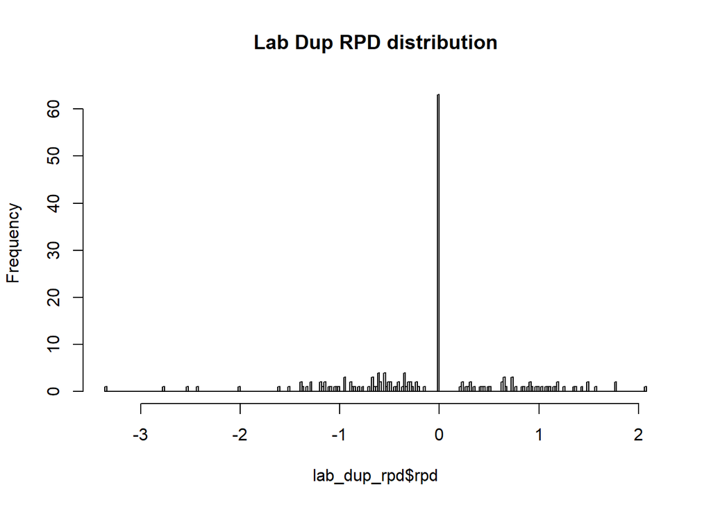

```r
# perform RPD calculation
lab_dup_rpd <- lab_dup1_wide2 %>%
  mutate(rpd =  100 * ((not_dup - lab_dup) / ((not_dup + lab_dup) / 2)))

hist(lab_dup_rpd$rpd, breaks=200, main = "Lab Dup RPD distribution")
```

## Evaluate field variance using Field Dup RPD for TDS

```r
#evaluate RPD between sample and field dup for TDS to get field method variance

#reassign qc category to properly assign "parent" to field dup including when used as lab dup
field_dup1 <- mutate(dset2_tds, field_dup_category = case_when(grepl("Replicate", sample_type) | grepl("Duplicate", sample_type)~"field_dup",
                                                           TRUE~"not_dup"))

field_dup2 <- mutate(field_dup1, main_id = case_when(parent_sample !="0" ~ paste(parent_sample),
                                                       TRUE ~ paste(sample_code)))

#remove all lab dups
field_dup3 <- filter(field_dup2, lab_dup == "")


field_dup3_wide <- field_dup3 %>%
  pivot_wider(id_cols = c(long_station_name, data_owner, main_id, collection_date),
              names_from = field_dup_category, values_from = result,
              values_fill = NA)

field_dup3_wide2 <- filter(field_dup3_wide, field_dup !="NA")
#count of 179 field dups is same as earlier, good to go

str(field_dup3_wide2)
```

```
## tibble [179 × 6] (S3: tbl_df/tbl/data.frame)
##  $ long_station_name: chr [1:179] "D19 - Frank's Tract near Russo's Landing" "NZS42 - Suisun Slough @ Volanti Slough" "D28A - Old River @ Rancho Del Rio" "NZ032 - Montezuma Slough nr Grizzly Island Club" ...
##  $ data_owner       : chr [1:179] "0310" "0310" "0310" "0310" ...
##  $ main_id          : chr [1:179] "E0124B0036" "E0124B0144" "E0224B0788" "E0224B1192" ...
##  $ collection_date  : Date[1:179], format: "2024-01-03" "2024-01-09" ...
##  $ not_dup          : chr [1:179] "548" "4750" "249" "1120" ...
##  $ field_dup        : chr [1:179] "536" "4740" "249" "1120" ...
```

```r
#change character values to numeric for rpd calculation
field_dup3_wide2$not_dup <- as.numeric(field_dup3_wide2$not_dup)
field_dup3_wide2$field_dup <- as.numeric(field_dup3_wide2$field_dup)

str(field_dup3_wide2)
```

```
## tibble [179 × 6] (S3: tbl_df/tbl/data.frame)
##  $ long_station_name: chr [1:179] "D19 - Frank's Tract near Russo's Landing" "NZS42 - Suisun Slough @ Volanti Slough" "D28A - Old River @ Rancho Del Rio" "NZ032 - Montezuma Slough nr Grizzly Island Club" ...
##  $ data_owner       : chr [1:179] "0310" "0310" "0310" "0310" ...
##  $ main_id          : chr [1:179] "E0124B0036" "E0124B0144" "E0224B0788" "E0224B1192" ...
##  $ collection_date  : Date[1:179], format: "2024-01-03" "2024-01-09" ...
##  $ not_dup          : num [1:179] 548 4750 249 1120 120 137 120 726 108 760 ...
##  $ field_dup        : num [1:179] 536 4740 249 1120 120 138 121 724 106 762 ...
```

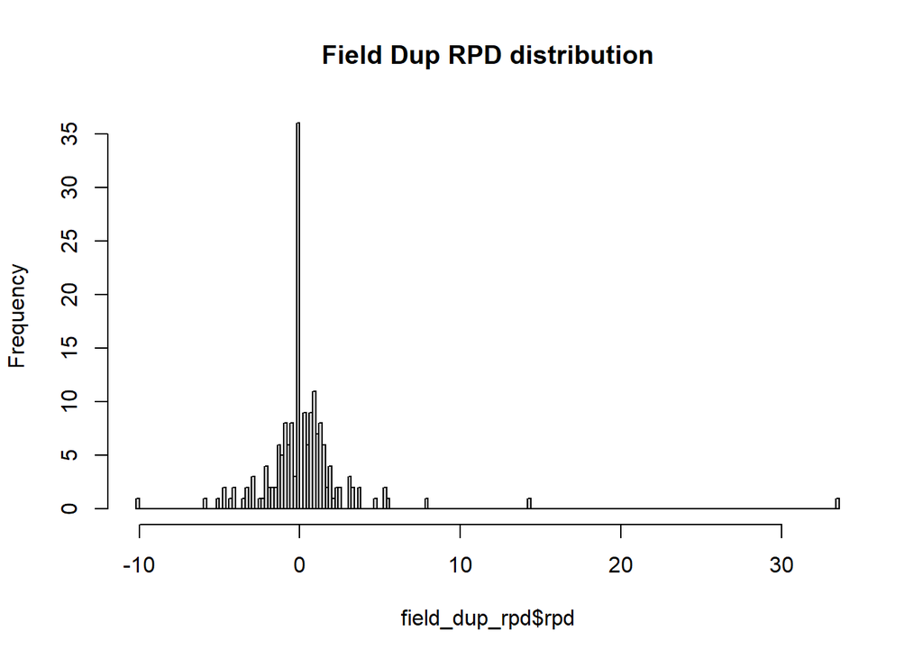

```r
# perform RPD calculation
field_dup_rpd <- field_dup3_wide2 %>%
  mutate(rpd =  100 * ((not_dup - field_dup) / ((not_dup + field_dup) / 2)))

hist(field_dup_rpd$rpd, breaks=200, main = "Field Dup RPD distribution")
```

#Evaluate Heteroscedasticity via RPD vs Absolute Difference ## Evaluate lab variance using Lab Dup AD for TDS

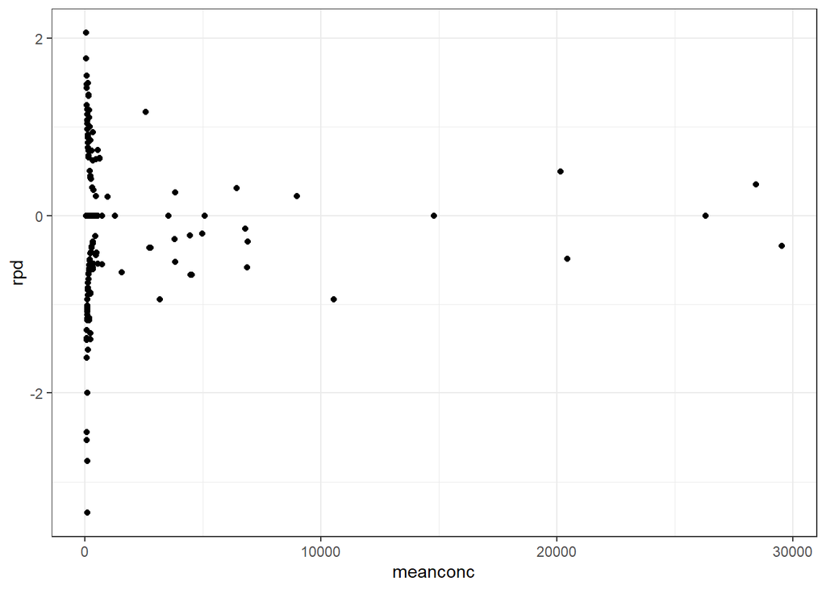

```r
ad_lab_dup_rpd <- lab_dup1_wide2 %>%
   mutate(rpd =  100 * ((not_dup - lab_dup) / ((not_dup + lab_dup) / 2)),
          ad = (not_dup - lab_dup),
          meanconc = (lab_dup+not_dup)/2)

# 100% of samples, rpd
 ggplot(ad_lab_dup_rpd, aes(meanconc, rpd)) +
   geom_point() +
   theme_bw()
```

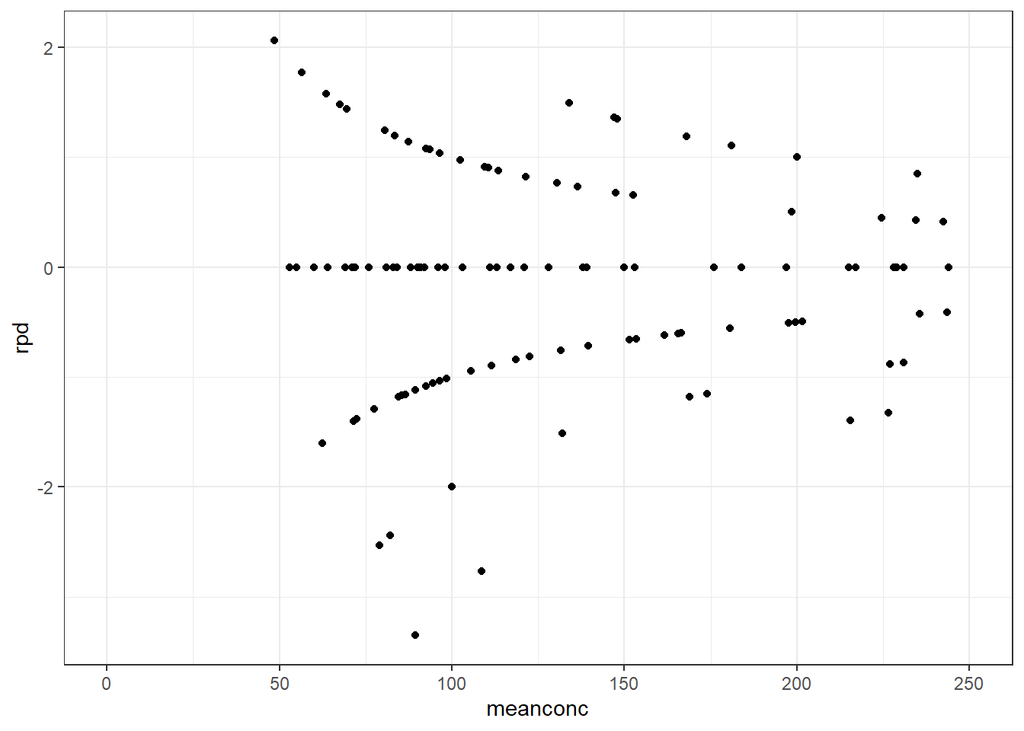

```r
# 65% of samples, rpd

 ggplot(ad_lab_dup_rpd, aes(meanconc, rpd)) +
   geom_point() +
   theme_bw() +
   xlim(0, 250)
```

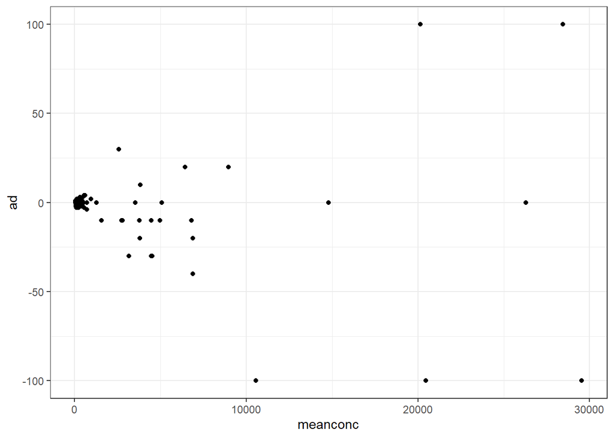

```r
# 100% of samples, ad

 ggplot(ad_lab_dup_rpd, aes(meanconc, ad)) +
   geom_point() +
   theme_bw()
```

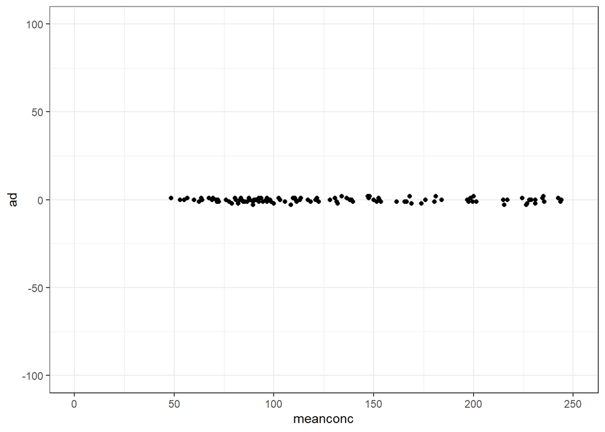

```r
# 65% of samples, ad

 ggplot(ad_lab_dup_rpd, aes(meanconc, ad)) +
   geom_point() +
   theme_bw() +
   xlim(0, 250)
```

## Evaluate field variance using Field Dup AD for TDS

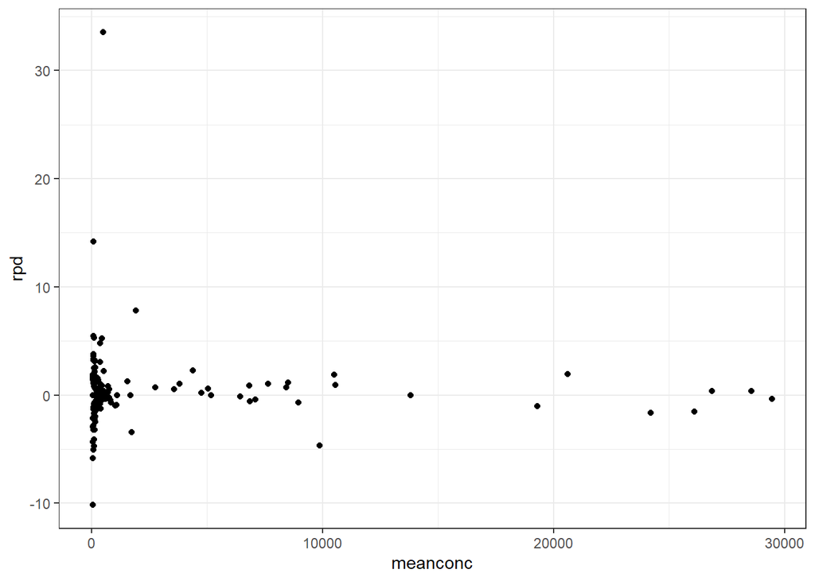

```r
ad_field_dup_rpd <- field_dup3_wide2 %>%
  mutate(rpd =  100 * ((not_dup - field_dup) / ((not_dup + field_dup) / 2)),
         ad = (not_dup - field_dup),
         meanconc = (field_dup+not_dup)/2)

# 100% of samples, rpd
ggplot(ad_field_dup_rpd, aes(meanconc, rpd)) +
  geom_point() +
  theme_bw()
```

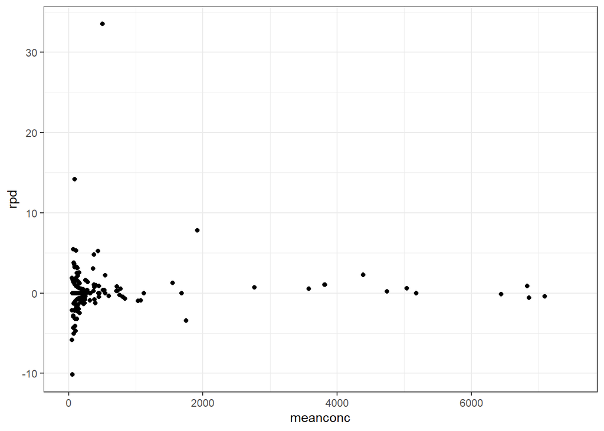

```r
# 94% of samples, rpd

ggplot(ad_field_dup_rpd, aes(meanconc, rpd)) +
  geom_point() +
theme_bw() +
  xlim(0, 7500)
```

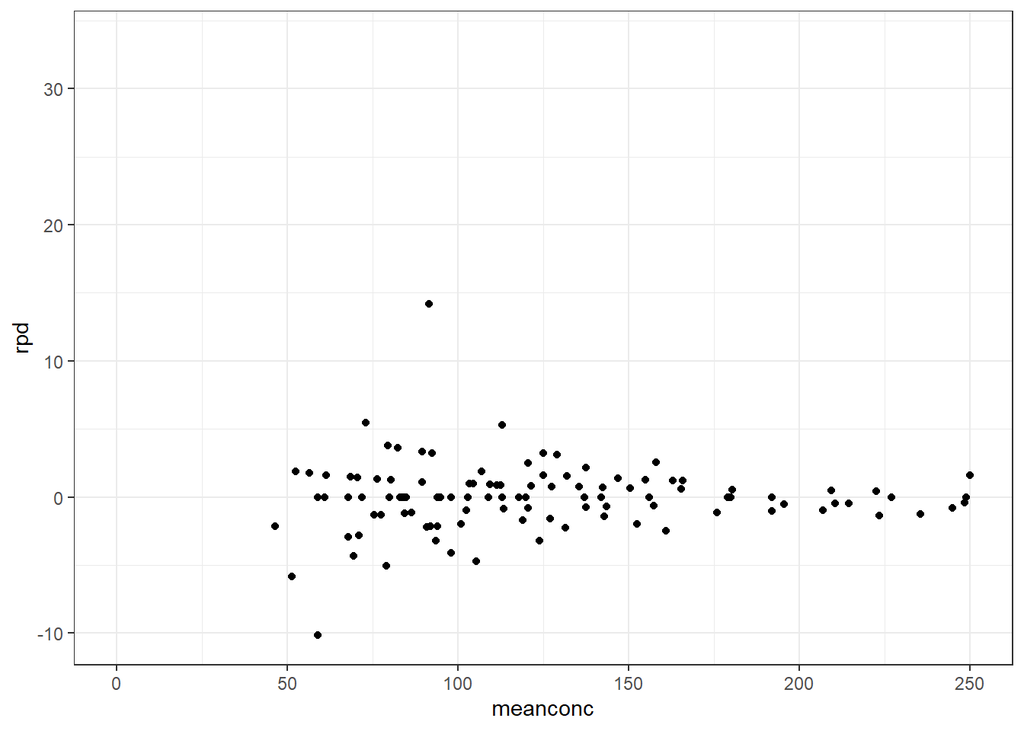

```r
# 63% of samples, rpd

ggplot(ad_field_dup_rpd, aes(meanconc, rpd)) +
  geom_point() +
  theme_bw() +
  xlim(0, 250)
```

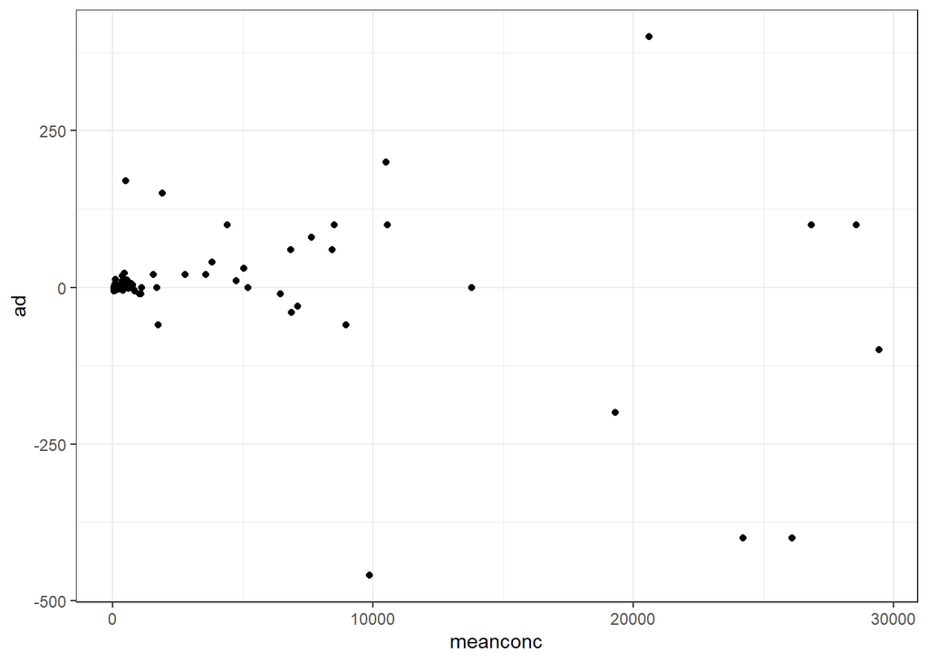

```r
# 100% of samples, ad
ggplot(ad_field_dup_rpd, aes(meanconc, ad)) +
  geom_point() +
  theme_bw()
```

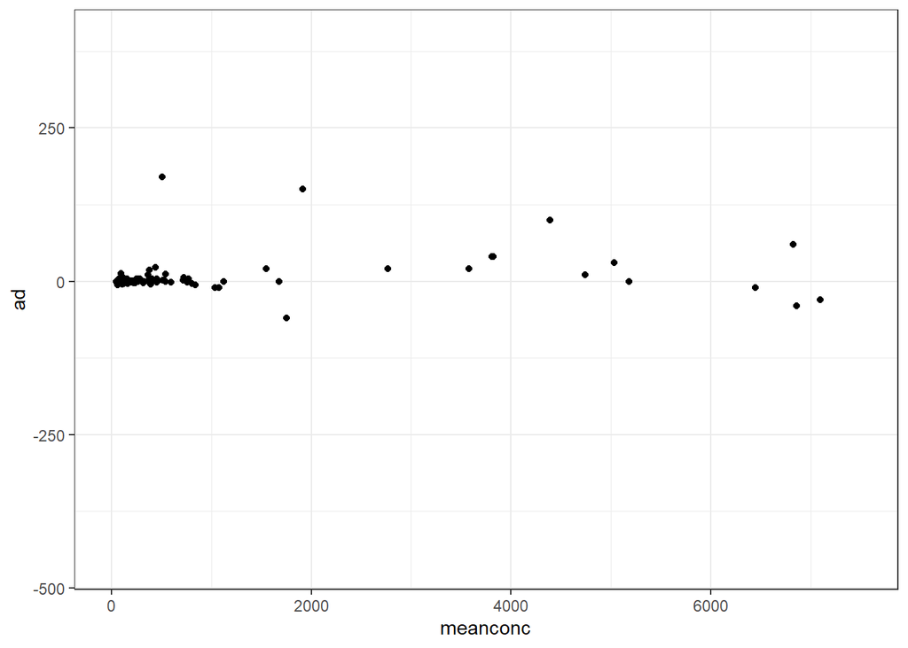

```r
# 94% of samples, ad
ggplot(ad_field_dup_rpd, aes(meanconc, ad)) +
  geom_point() +
  theme_bw() +
  xlim(0, 7500)
```

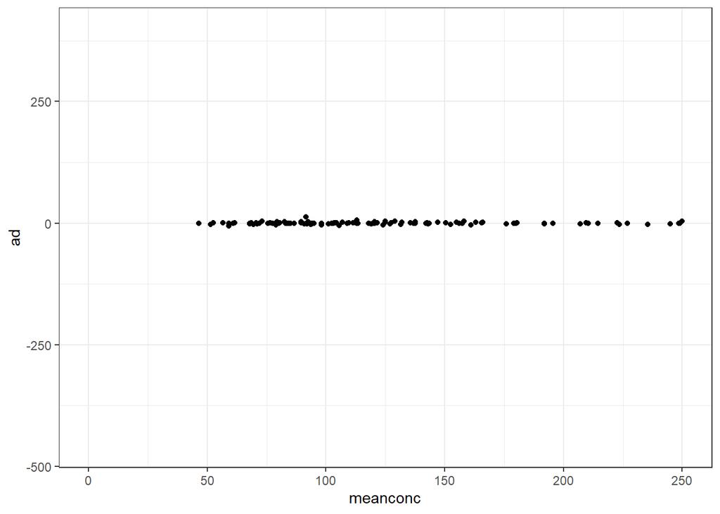

```r
# 63% of samples, ad

ggplot(ad_field_dup_rpd, aes(meanconc, ad)) +
  geom_point() +
  theme_bw() +
  xlim(0, 250)
```

#Power Analysis Decision made to use absolute difference (AD) as measure of variance rather than relative percent difference (RPD) and focus on TDS concentrations at mean to address heteroscedasticity issue.

## Assumptions

- New method (performed by lab) has a single iteration
- Historic methods vary in multiple ways, focused on 3 parameters (filter type, filter material, filter surface area)
  - **Question 1: Is there a statistically significant difference between the historic and new methods?**
  - **Question 2: Are any of the parameters within historic method contributing in a statistically significant way to this effect?**

## Study Design

- Ideally have an equal number of samples covering each of the 3 main parameters that define a method
  - Particularly curious about iterations of capsule filter method which has unique type, material, and surface area than others.

## Analysis of Data

- Use linear regression models

### Question 1

Will use the following model:

$$log(Y_{TDS}) \sim X_{new} +
(1|X_{pair})$$

where: $log(Y_{TDS})$: TDS concentration (log because parent/duplicate samples have a power law relationship)

$X_{new}$: if it’s the new method or the old method

$1|X_{pair}$: a random effect that ties the two paired old/new values together

- can just use $Date$ if they don’t overlap (NOTE: if each pair was sampled on a different date, then Date already uniquely specifies the pairs and X_date = X_pair) ##Still don’t get this and what to use, need to f/u with Perry (KJR 1/5/26)

### Question 2

Plan to look at capsule filter itself specifically to assess whether the effect of this filter type in the historic method contributes to a statistically significant difference between the historic and new methods.

$$log(Y_{TDS}) \sim X_{new} +
X_{old,capsule filter} + X_{new}X_{old,capsule filter} +
(1|X_{pair})$$

where:

$X_{old,capsule filter}$ is the use of capsule filter type within the old method

# Power Assessment

Using Cohen’s $f^2$ test to determine the number of samples needed for a given power.

Needed information:

- estimate of effect size
- number of covariates
- desired Type I and Type II error rate

## effect size

Using the relationship between actual parent-duplicate paired samples, whether they are truly duplicates of one another.

Assessing this by using a log-log (power law) relationship between the parent/duplicate samples. Valid based on the error distribution between the two; it’s not linear in “regular” space and is linear in log-log space. Do for both field duplicates and lab duplicates.

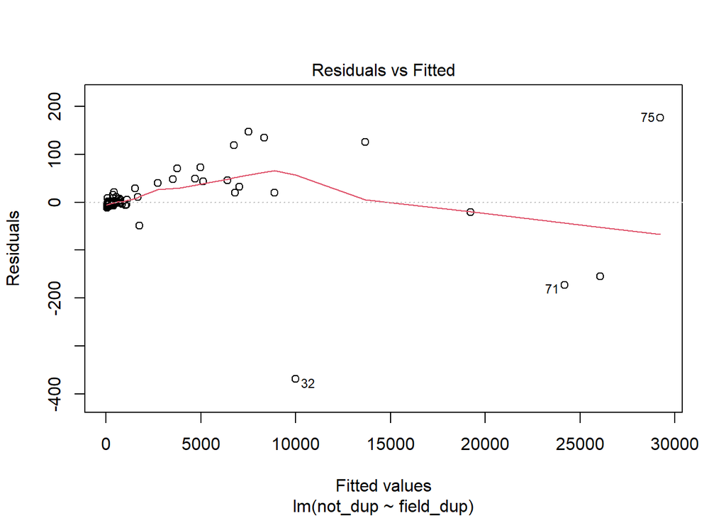

```r
df_fd <- ad_field_dup_rpd %>% filter(ad < 100) # remove extreme outliers (9 total)
mod2 <- lm(not_dup ~ field_dup, data = df_fd)

# this is the same as a parent-dup vs. [parent+dup]/2 plot, ie. error vs mean
plot(mod2, which = 1)
```

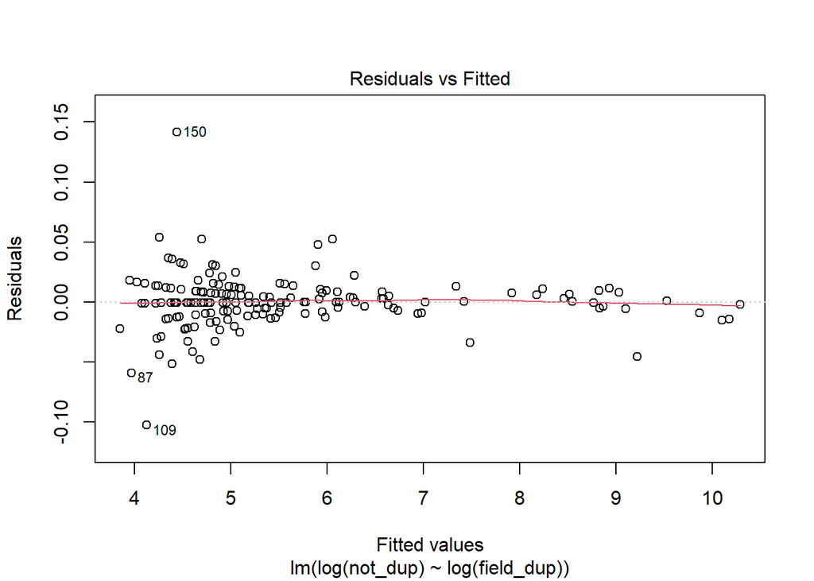

```r
mod1 <- lm(log(not_dup) ~ log(field_dup), data = df_fd)

# this is the same as a log(parent)-log(dup) vs. [log(parent)+log(dup)]/2 plot, ie. error vs mean
plot(mod1, which = 1)
```

```r
summary(mod1)
```

```
##
## Call:
## lm(formula = log(not_dup) ~ log(field_dup), data = df_fd)
##
## Residuals:
##       Min        1Q    Median        3Q       Max
## -0.102668 -0.009126 -0.000500  0.008932  0.141541
##
## Coefficients:
##                Estimate Std. Error t value Pr(>|t|)
## (Intercept)    0.002334   0.006841   0.341    0.733
## log(field_dup) 0.999649   0.001185 843.557   <2e-16 ***
## ---
## Signif. codes:  0 '***' 0.001 '**' 0.01 '*' 0.05 '.' 0.1 ' ' 1
##
## Residual standard error: 0.02272 on 168 degrees of freedom
## Multiple R-squared:  0.9998, Adjusted R-squared:  0.9998
## F-statistic: 7.116e+05 on 1 and 168 DF,  p-value: < 2.2e-16
```

Can use $R^2$ here as an effect size estimate based on field variance, equals 0.9998 ie., basically 1. Very high and best to add some flexibility and lower this $R^2$.

Note: the field_dup coefficient being ~1 means there’s a 1% change in parent concentration per 1% change in duplicate concentration, ie., they’re essentially the same thing)

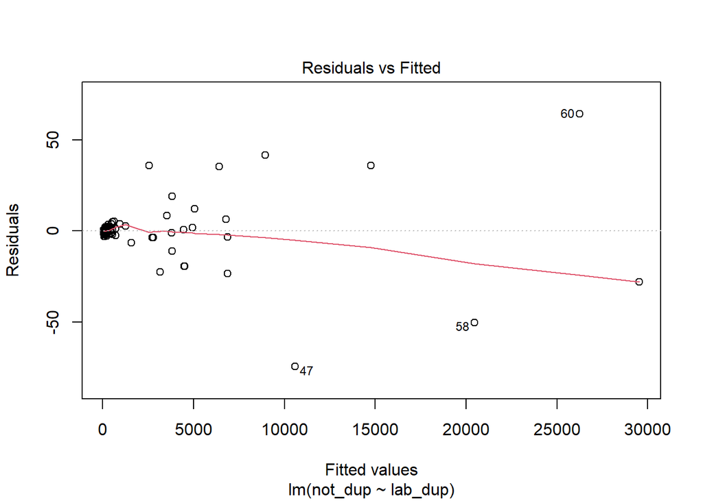

```r
df_ld <- ad_lab_dup_rpd %>% filter(ad < 100) # remove extreme outliers (2 total)
mod4 <- lm(not_dup ~ lab_dup, data = df_ld)

# this is the same as a parent-dup vs. [parent+dup]/2 plot, ie. error vs mean
plot(mod4, which = 1)
```

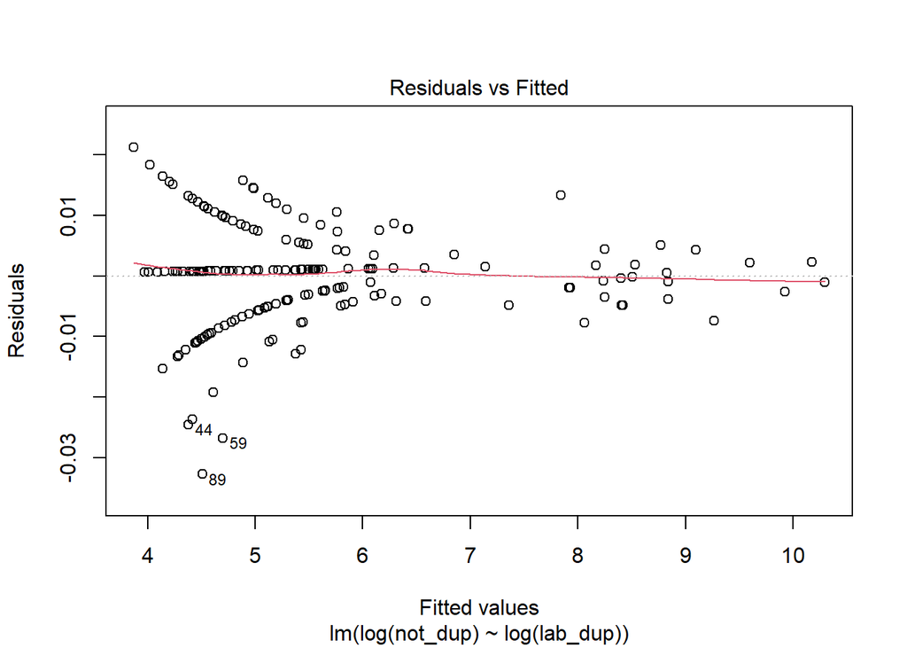

```r
mod3 <- lm(log(not_dup) ~ log(lab_dup), data = df_ld)

# this is the same as a log(parent)-log(dup) vs. [log(parent)+log(dup)]/2 plot, ie. error vs mean
plot(mod3, which = 1)
```

```r
summary(mod3)
```

```
##
## Call:
## lm(formula = log(not_dup) ~ log(lab_dup), data = df_ld)
##
## Residuals:
##       Min        1Q    Median        3Q       Max
## -0.032731 -0.004165  0.000793  0.003515  0.021237
##
## Coefficients:
##               Estimate Std. Error  t value Pr(>|t|)
## (Intercept)  0.0004323  0.0025248    0.171    0.864
## log(lab_dup) 0.9997287  0.0004426 2258.964   <2e-16 ***
## ---
## Signif. codes:  0 '***' 0.001 '**' 0.01 '*' 0.05 '.' 0.1 ' ' 1
##
## Residual standard error: 0.008333 on 180 degrees of freedom
## Multiple R-squared:      1,  Adjusted R-squared:      1
## F-statistic: 5.103e+06 on 1 and 180 DF,  p-value: < 2.2e-16
```

Can use $R^2$ here as an effect size estimate based on lab variance, equals 1. Also still will add some flexibility and lower this $R^2$.

## Covariates

- for Question 1, this is 2 ($X_{new}$ and $X_{pair}$)
- for Question 2, this is 2 + 2*(the number of levels in the categorical variable-1).
  - In currently effective field SOP (DWR-1-SOP-004_v4.0), there are 4 approved filtration techniques (disc filtration apparatus, plate filtration appratus, stainless-steel filtration apparatus, capsule filter), 4 approved materials for these filters (nitrocellulose, mixed cellulose ester, versapore, PES), and 3 filter diameters/surface areas (47mm, 142 mm, med capacity capsule filter).
- Set as 2+3(filtration technique levels-1)+3(filter material levels-1) + 2(filter diameter levels-1) = 10

## final power estimation

Assuming Type 1 error rate of 1% and Type 2 error rate of 10% (so 90% power)

```r
##original that I had:
# f2 = R^2/(1-R^2), using 0.8
# f2 = explained variance/unexplained variance; so f2 = 1 means there's a 1:1 ratio
##

##updated 1/5/26 with Perry's input on f2 equation and R^2 update
# f2 = 1-R^2, increasing R^2 from 0 to 0.3 to account for covariates


pwr_calc_old <- pwr.f2.test(u = 10, f2 = (0.8/(1-0.8)), sig.level = 0.01, power = 0.9)

pwr_calc_new <- pwr.f2.test(u = 10, f2 = (1-0.3), sig.level = 0.01, power = 0.9)

pwr_calc_new
```

```
##
##      Multiple regression power calculation
##
##               u = 10
##               v = 39.92103
##              f2 = 0.7
##       sig.level = 0.01
##           power = 0.9
```

Number of samples $N$ would be $v+1+u$, where $u$ is the number of covariates:

```r
samp_size <- pwr_calc_new$v+1+10

samp_size
```

```
## [1] 50.92103
```

So I’d need ~50 samples **in total**.

**Note** the model doesn’t account for the fact that I want to split this across field groups.

```r
unique(dset3_tds_wide$data_owner)
```

```
## [1] "0330" "0310" "6200" "6301" "4804" "2040" "7200" "1860"
```

```r
#8 different programs

count(dset3_tds_wide, data_owner)
```

```
## # A tibble: 8 × 2
##   data_owner     n
##   <chr>      <int>
## 1 0310         313
## 2 0330         146
## 3 1860          75
## 4 2040         383
## 5 4804         234
## 6 6200         116
## 7 6301          75
## 8 7200          44
```